# Novedades en la Enucesta de Turismo Internacional (ETI)

Resultado de trabajo conjunto con el Instituto Nacional de Estadística y Censos (INDEC)

En el día de hoy publicamos los datos correspondientes al mes de septiembre 2022 del turismo internacional para el total nacional, por todos los medios de transporte utilizados (aéreos, fluviales, marítimos y terrestres). A su vez, también el INDEC publicó la Encuesta de Turismo Internacional (MINTURDEP-INDEC) con datos de septiembre y del tercer trimestre del año para los pasos relevados (Ezeiza, Aerop. J. Newbery, Aerop. de Córdoba, Aerop. de Mendoza, Cristo Redentor y Puerto de Buenos Aires)

## Novedades

Hasta ahora en el informe de prensa de la ETI se publicaban los datos del turismo internacional correspondientes a los pasos fronterizos relevados por la encuesta y el movimiento del total de la vía aérea. Nosotros, por otro lado, publicamos los datos del total país por todas las vías. Esto muchas veces generaba confusiones o malas interpretaciones entre ambos números publicados. Por ello, **se decidió incluir los datos del total nacional en el informe de prensa de la ETI** y así mejorar la interpretación de la información comunicada.

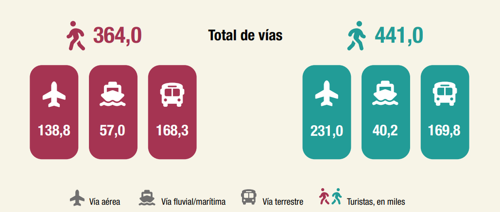

Figure 1: Estimación de Turismo Internacional por todas las vías, septiembre 2022

**Encuesta de Turismo Internacional (ETI) - Septiembre 2022**

📝 [Informe](https://www.indec.gob.ar/uploads/informesdeprensa/eti_11_22A333204044.pdf)

Esta decisión es el resultado del compromiso de trabajo conjunto con el equipo de la Dirección Nacional de Estadísticas del Sector Externo y Cuentas Internacionales del INDEC, con quienes elaboramos todos los meses los datos de turismo internacional y realizamos la encuesta de turismo. Creemos que, de esta manera, la difusión de la información del turismo receptivo y emisivo de nuestro país será más clara y permitirá un mejor análisis de su evolución.

Algunos puntos que vale la pena destacar:

**(1)** en los informes hemos renombrado la unidad de análisis que contabilizamos todos los meses. En pos de definir mejor la terminología utilizada, según las definiciones internacionales de turismo, lo que antes llamábamos “turistas”, ahora lo renombramos como “viajes de turistas” tanto para el turismo receptivo como el emisivo. Por su parte, ahora la ETI distingue los viajes (de turistas o excursionistas) de los visitantes en tanto personas (turistas o excursionistas).

Para que se entienda la diferencia rápidamente nos valemos del siguiente ejemplo:

> **si un español viene a la argentina, visita Uruguay por unos días y luego vuelve y sigue recorriendo nuestro país, según las recomendaciones internacionales, se deben contabilizar dos viajes (el transcurrido desde que llega a la Argentina hasta que se va a Uruguay y luego cuando vuelve de allí y sale definitivamente del país) y un visitante.**

Un mismo visitante puede realizar más de un viaje turístico. Ambas unidades de análisis (viajes y visitantes) serán contabilizadas y comunicadas en el informe de prensa de la ETI a partir de la publicación del día de hoy.

**(2) Datos 2022**: han sido rectificados debido a una mejor operacionalización de los criterios utilizados, pero se mantiene la misma metodología de estimación.

**(3) Metodología**: este trabajo conjunto con INDEC para estimar el turismo internacional se basa en los registros migratorios brindados por la Dirección Nacional de Migraciones del Ministerio del Interior. Esta fuente de datos y la metodología diseñada fueron claves, por ejemplo, en épocas de restricciones por la pandemia del Covid19, cuando las encuestas de turismo internacional se suspendieron y no se contaba con información suficiente para realizar las estimaciones de turismo de nuestro país. Con ese impulso se comenzó a trabajar con los datos de registros migratorios de forma más exhaustiva, posibilitando la publicación de los datos del turismo en nuestro país.

Es a partir de esta experiencia que hoy podemos calcular el flujo de viajes y visitantes (turistas y excursionistas) para todo el país en el informe de la ETI. Más allá de su publicación mensual, esta metodología funciona como instrumento de uso interno muy relevante para hacer un seguimiento de la evolución del turismo internacional con una mayor frecuencia a la publicada.

Toda esta información está disponible en las distintas secciones del **Sistema de Información Turístico de la Argentina (SINTA)**:

• **Tablero de turismo internacional**:

https://tableros.yvera.tur.ar/turismo_internacional/

• **Informes de prensa**:

https://www.yvera.tur.ar/sinta/informe/info/turismo-internacional

• **Reportes**:

https://tableros.yvera.tur.ar/internacional.html